# rational incremental predictive pragmatic processing

\[ \definecolor{firebrick}{RGB}{178,34,34} \newcommand{\red}[1]{{\color{firebrick}{#1}}} \] \[ \definecolor{green}{RGB}{107,142,35} \newcommand{\green}[1]{{\color{green}{#1}}} \] \[ \definecolor{blue}{RGB}{0,0,205} \newcommand{\blue}[1]{{\color{blue}{#1}}} \] \[ \newcommand{\den}[1]{[\![#1]\!]} \] \[ \newcommand{\set}[1]{\{#1\}} \] \[ \newcommand{\tuple}[1]{\langle#1\rangle} \]

\[\newcommand{\States}{{T}}\] \[\newcommand{\state}{{t}}\] \[\newcommand{\Messgs}{{M}}\] \[\newcommand{\messg}{{m}}\]

## roadmap

language processing

levels of analysis

rational speech act model

experimental data

model fits

reflection

## processing?

## incremental & predicitive processing

processing

- comprehension of serially presented written or oral language input in context

incrementality

- build a syntactic & semantic representations as the sentence comes in
  - what's the increment size? fixed or variable?
  - how to deal with ambiguity? singular guess or parallel hypotheses?

predicitive

- minimal sense: processing behavior is a function of current state
- strong(est) sense: comprehender entertains hypotheses about the future

(Kuperberg & Jaeger 2016)

## levels of analysis

## levels of analysis

computational

algorithmic

implementational

(Marr 1982)

## levels of analysis

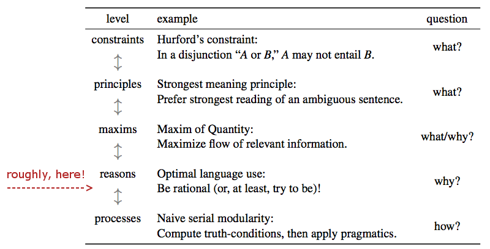

(Franke & Jäger 2016)

## algorithmic-level accounts

[figure not shown]

## mechanics of scalar implicature processing

what?

1. compute SI
2. verify SI
3. integrate/cancel SI

when?

1. scalar item
2. full NP
3. matrix clause

how?

1. costly
2. delayed
3. cheap & immediate

whence?

1. automatic
2. voluntary
3. context-dependent

## hypothesis testing

pick account

derive some (excentric) prediction

design experiment

refute & repeat

(Platt 1964)

## computational-level accounts

[figure not shown]

## notions of "explanation"

description <———————————————–> reason

diagnostics

how would it work on Tralfamadore?

could you conceive of it without seeing any data?

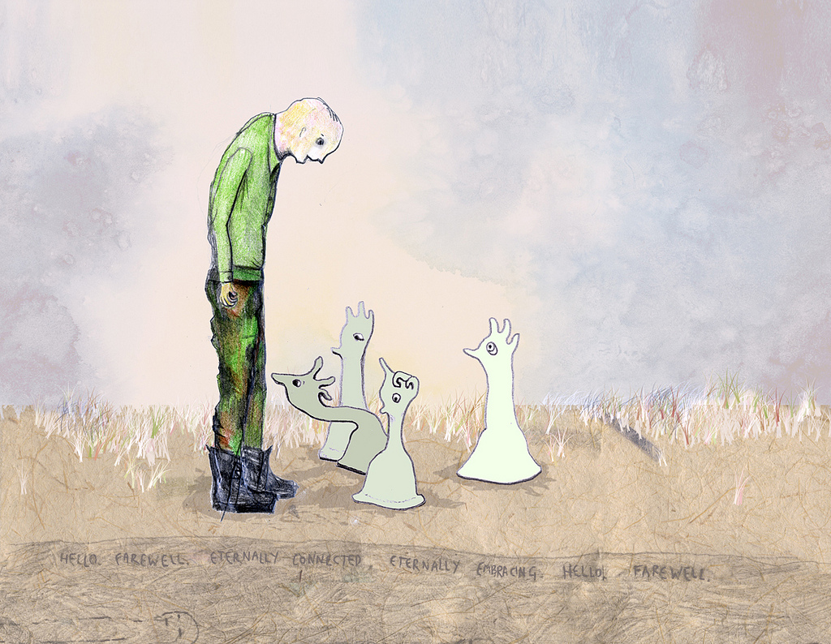

## expectation-based processing accounts

- basic premisse: anticipation is an advantage
- (maximally) predictive interpreter has lexico-syntactic expecations \(P(w_1, \dots, w_n \mid c)\)
  - operationalized by corpus frequencies of relevant structures
  - possible beam-search approximation
  - derived expectation about continuation \(P(w_{i+1}, \dots, w_n \mid w_1, \dots, w_i, c)\)
- processing difficulty linked to distance between \(P(\cdot \mid w_1, \dots, w_\red{i}, c)\) and \(P(\cdot \mid w_1, \dots, w_\red{i+1}, c)\)
  - self-paced reading times (Smith & Levy 2013)
  - various ERP components, notably N400 amplitude (Frank et al. 2015)

(e.g., Jurafsky 1996, Hale 2006, Levy 2008)

## rational pragmatic processors

## rational speech act model

literal listener picks literal interpretation (uniformly at random):

\[ P_{LL}(t \mid m) \propto P(t \mid [\![m]\!]) \]

Gricean speaker approximates informativity-maximization:

\[ P_{S}(m \mid t) \propto \exp( \lambda P_{LL}(t \mid m)) \]

pragmatic listener uses Bayes' rule to infer likely world states:

\[ P_L(t \mid m ) \propto P(t) \cdot P_S(m \mid t) \]

interpretation as holistic: full & complete utterance

(e.g., Benz 2006, Frank & Goodman 2012)

## incremental & predicitive interpretation

- messages are word sequences: \(\messg = w_1, \dots, w_n\)
- initial subsequence of \(\messg\): \(\messg_{\rightarrow i} = w_1, \dots w_i\)
- all messages sharing initial subsequence: \(\Messgs(\messg_{\rightarrow i}) = \set{\messg' \in \Messgs \mid \messg'_{\rightarrow i} = \messg_{\rightarrow i}}\)
- next-word expectation:

\[P_L(w_{i+1} \mid \messg_{\rightarrow i}) \propto \sum_{\state} P(\state) \ \sum_{\messg' \in \Messgs(\messg_{\rightarrow i}, w_{i+1})} P_S(\messg' \mid \state)\]

- interpretation evidence:

\[P_L(\state \mid \messg_{\rightarrow i}) \propto P(\state) \ \sum_{\messg' \in \Messgs(\messg_{\rightarrow i})} P_S(\messg' \mid \state)\]

## empirical measures

next-word

- self-paced reading
- eye-tracked reading
- ERPs
- …?

interpretation

- visual worlds
- mouse-tracking
- …?

## ERP traces of scalar implicature

## some EEG studies on some

Noveck & Posada (2003)

- ERPs on last word during reading: e.g. "Some people have fins/lungs/pets."
- N400 amplitude: "pets" > "lungs"

Nieuwland et al. (2010)

- similar to Noveck & Posada
- two types of responders based on Autism Spectrum Quotient
  - low ASQ: "lungs" > "pets" ; high ASQ: "lungs" \(\approx\) "pets"

Hunt et al. (2013)

- sentences with pictorial contexts: controls for lexical associations
- truth-value judgement after each sentence
- semantic vs. pragmatic responders
- pragmatic resonders' N400: false > underinformative > true & felicitous

Spychalska et al. (2016)

- similar to Hunt, but more careful design
- no explanatory role for ASQ scores
- strong explanatory role for responder type
- explicit focus on next-work prediction

## experiment 1

participants & procedure

- EEG recording of 25 native German speakers
- picture (1500ms) -> sentence (500ms per word) -> truth-value judgement

sentence material

- "Alle/Einige\(_1\) Punkte sind blau\(_2\), die im Kreis/Quadrat\(_3\) sind"
- "All/some of the dots in the circle/square are blue/red"

visual stimuli

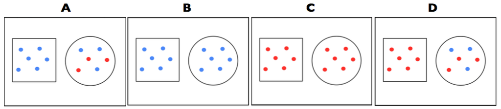

## computational-level rational processing

general assumptions

- listener expects speaker to make a pragmatically felicitous utterance
- listener does not give up on speaker rationality on the way (charity, forward induction, …)

experimental microcosmos assumption

- possible meanings \(\States\): pairs of contexts (\(A\) - \(D\)) and speaker-intended shape
- possible messages \(\Messgs\): "All/some dots are blue/red that are in the square/circle."

specific assumptions

- listener knows context, but not shape
- speaker chooses description for context and shape

## next-word expectations vs. N400

- incremental RSA predicts \(P_L(w_{i+1} \mid w_{1,\dots,i}, c)\)
- correlating predicted next-word expectations grand-average early N400 (300-400ms):
  - \(r= 0.44\), \(p < 0.01\) in total
  - \(r = 0.81\), \(p < 0.001\) after exclusion of unexpected continuations

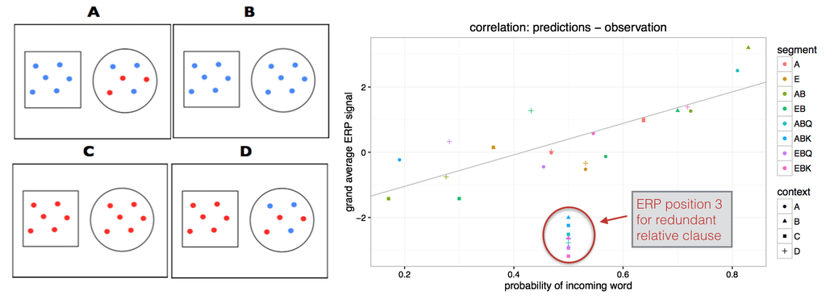

## closer look: quantifier position

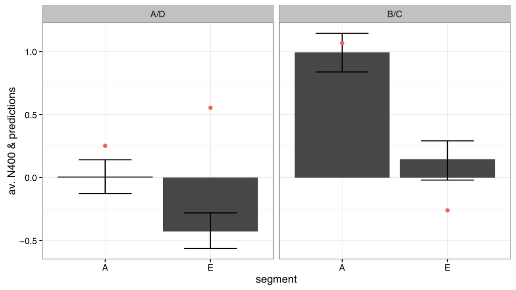

## closer look: adjective position

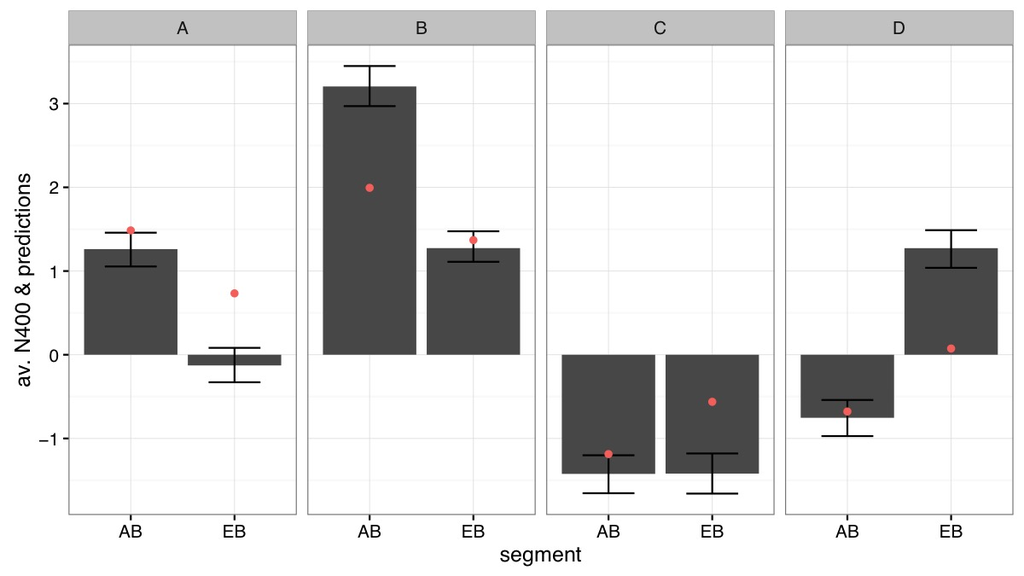

## closer look: shape noun position

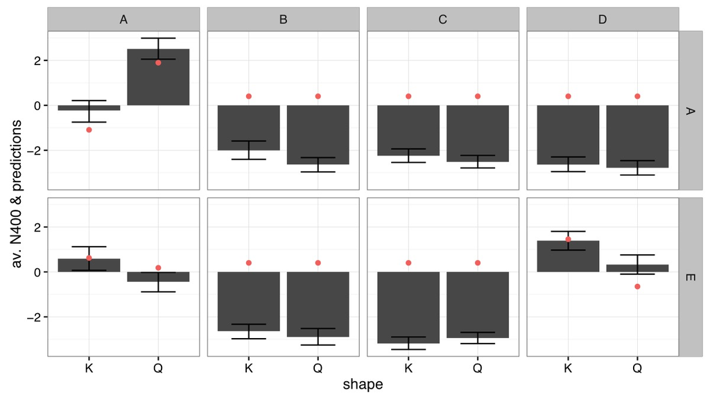

## semantic vs. pragmatic responders

## semantic vs. pragmatic responders

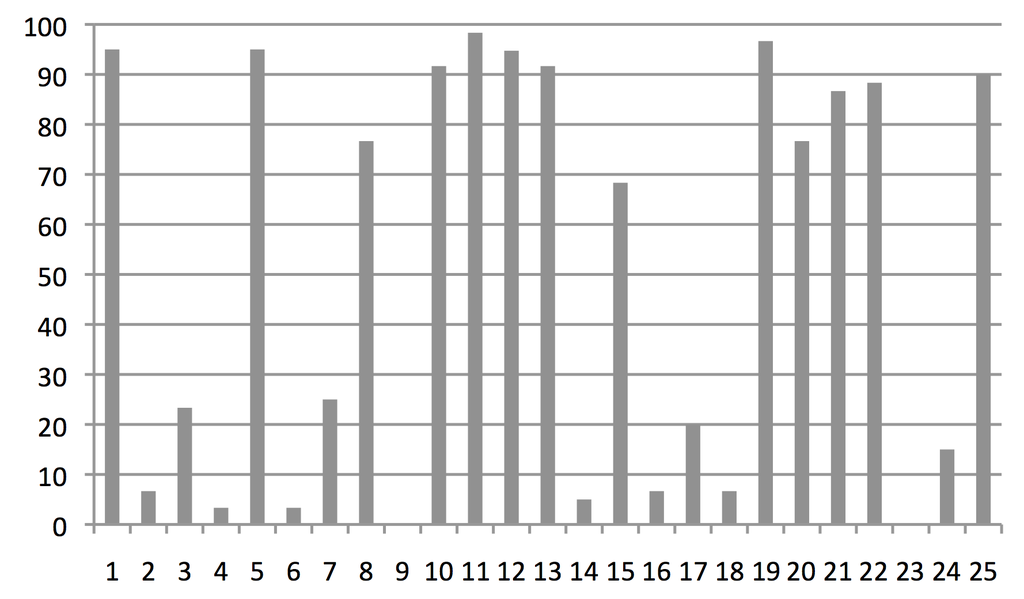

percentage of pragmatic responses per participant

## predictions for response types

pragmatic responders

expect pragmatic speakers

\[P(\text{more informative true}) > P(\text{less informative true}) > P(\text{false})\]

semantic responders

expect literal speakers

\[P(\text{more informative true}) = P(\text{less informative true}) > P(\text{false})\]

(Franke 2012, Franke & Degen 2016)

## results

- correlation between predictions and observation (expluding redundant relative clauses):
  - \(r= 0.69\), \(p < 0.01\) for pragmatic responders
  - \(r = 0.57\), \(p < 0.01\) for semantic responders

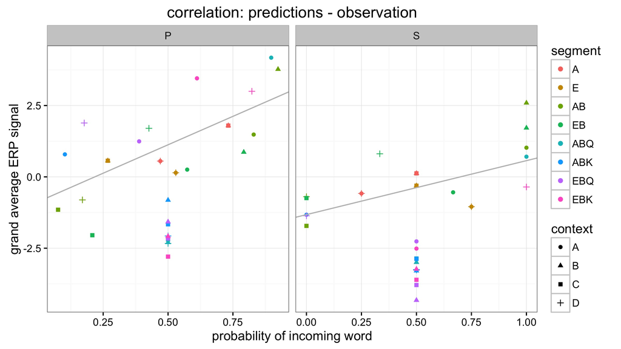

## further issues

## experimental microcosmos

main issue

how to fix reasonable \(\States\) and \(\Messgs\)?

experimental microcosmos assumption

all (and only?) meanings and forms that occur in the experiment

prediction

massive influence of filler material

## experiment 2

participants & procedure

- EEG recording of 24 native German speakers
- picture (1500ms) -> sentence (500ms per word) -> truth-value judgement

sentence material

- "Einige\(_1\) Punkte sind blau\(_2\), die im Kreis/Quadrat\(_3\) sind"
- "Einige\(_1\) Punkte sind blau\(_2\)"

visual stimuli

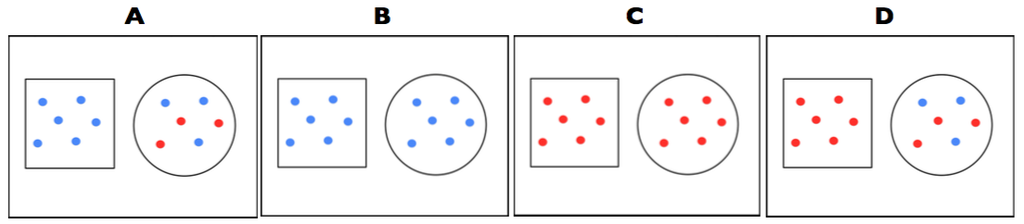

## results

behavioral data

only one participant consistently gave pragmatic judgements

ERP responses

no trace of pragmatic infelicity / expectations

## conclusions

## conclusions

- incremental RSA seems feasible:
  - next-word expecations & accummulated interpretation evidence
  - genuine pragmatic expectations beyond / on top of lexico-pragmatic expectations
- main challenges:
  - link functions for interesting experimental measures
  - how to fix \(\States\) and \(\Messgs\) in general?
  - how to scale up to more open-ended applications? tradeoff lexico-syntactic vs. pragmatic expectations?